# Logistic Regression

## Linear Regression

### Things You Should Know

- Model parameter interpretation
- Hypothesis tests for slopes and intercept
- Confidence intervals for slopes and intercepts
- Confidence versus prediction intervals
- Model assumptions and how to check them using diagnostic plots

## Odds

Odds are another way of quantifying the probability of an event, used in gambling and logistic regression.

For some event \(E\) \[ odds(E) = \frac{Pr(E)}{1-Pr(E)} = \frac{x}{y}\] \[ Pr(E) = \frac{odds(E)}{1+odds(E)}=\frac{x}{x+y}\]

## Generalized Linear Models - characteristics

- A probability distribution for the outcome
- A linear model \[ \eta = \beta_0 + \beta_1X_1 + \cdots + \beta_pX_p\]
- A link function \[ g(\mu) = \eta\]

## Logistic Regression

- GLM for binary \(\{0,1\}\) data
- Assumes a bernoulli/binomial distribution for the outcome.
- Given a set of predictors \(X\) (categorical and numeric).
- Want to model \(E[Y|X] = p\), the probability of success.
- Use the logit link function \[ logit(p) = \log\left(\frac{p}{1-p}\right) \]

## Logit function

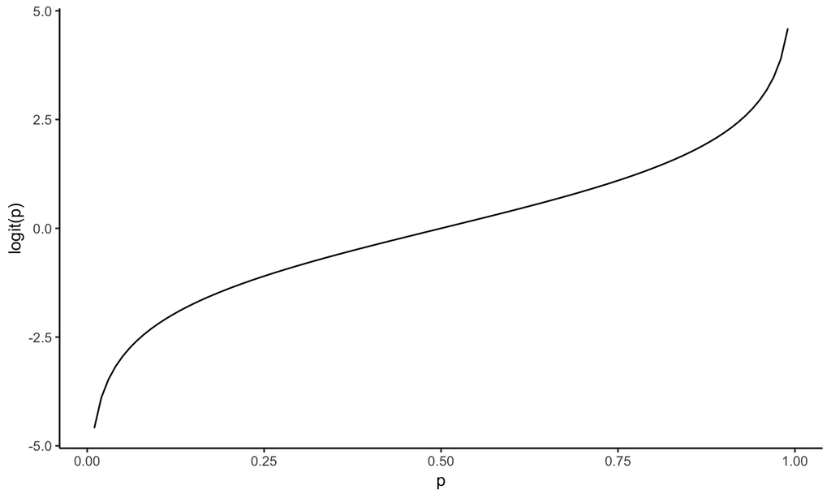

## Expit Function

\[ expit(\eta) = \frac{\exp(\eta)}{1+\exp{\eta}}\]

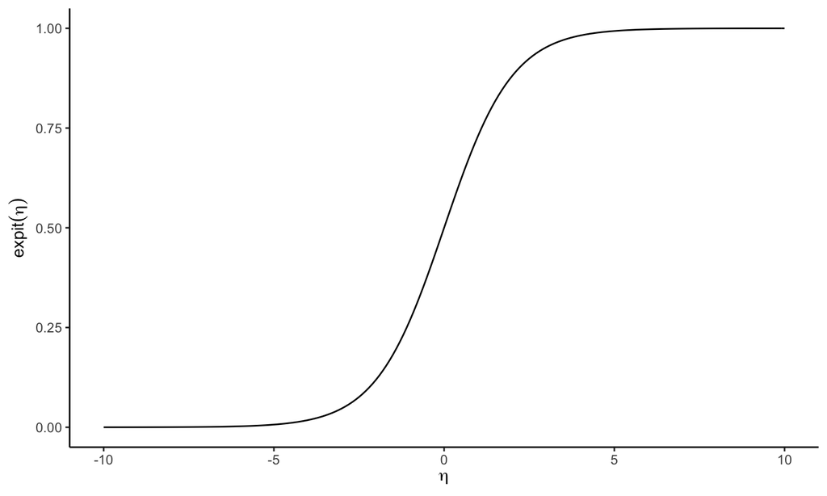

## Logistic Regression Model

\[y_i \sim Binom(n=1, p_i)\] \[\eta_i = \mathbf{x_i}^T\beta\] \[logit(p_i) = \eta_i\]

\[p_i = \frac{\exp(\mathbf{x_i}^T\beta)}{1+\exp(\mathbf{x_i}^T\beta)}\]

## Donner data

In 1846 the Donner and Reed families left Springfield, Illinois, for California by covered wagon. In July, the Donner Party, as it became known, reached Fort Bridger, Wyoming. There its leaders decided to attempt a new and untested rote to the Sacramento Valley. Having reached its full size of 87 people and 20 wagons, the party was delayed by a difficult crossing of the Wasatch Range and again in the crossing of the desert west of the Great Salt Lake. The group became stranded in the eastern Sierra Nevada mountains when the region was hit by heavy snows in late October. By the time the last survivor was rescued on April 21, 1847, 40 of the 87 members had died from famine and exposure to extreme cold.

## Donner Data

|  | family | age | sex | survived | death |
| --- | --- | --- | --- | --- | --- |
| Antoine | Other | 23 | Male | 0 | 1846-12-29 |
| Breen, Edward | Breen | 13 | Male | 1 | NA |
| Breen, Margaret I. | Breen | 1 | Female | 1 | NA |
| Breen, James | Breen | 5 | Male | 1 | NA |
| Breen, John | Breen | 14 | Male | 1 | NA |
| Breen, Mary | Breen | 40 | Female | 1 | NA |

## Fit a logistic regression model

```r
summary(glm(survived~age+sex+family, data=Donner, family = binomial))
```

```
##
## Call:
## glm(formula = survived ~ age + sex + family, family = binomial,
##     data = Donner)
##
## Deviance Residuals:
##      Min        1Q    Median        3Q       Max
## -2.07065  -0.78425   0.00018   0.83084   2.27817
##
## Coefficients:
##                   Estimate Std. Error z value Pr(>|z|)
## (Intercept)       19.48229 1226.69283   0.016   0.9873
## age               -0.04161    0.01923  -2.164   0.0304 *
## sexMale           -1.32700    0.59592  -2.227   0.0260 *
## familyDonner     -18.17917 1226.69277  -0.015   0.9882
## familyEddy       -19.50763 1226.69327  -0.016   0.9873
## familyFosdWolf   -17.89283 1226.69304  -0.015   0.9884
## familyGraves     -17.16864 1226.69282  -0.014   0.9888
## familyKeseberg   -18.11527 1226.69308  -0.015   0.9882
## familyMcCutchen  -17.42154 1226.69336  -0.014   0.9887
## familyMurFosPik  -18.16684 1226.69276  -0.015   0.9882
## familyOther      -18.16807 1226.69264  -0.015   0.9882
## familyReed       -15.69515 1226.69311  -0.013   0.9898
## ---
## Signif. codes:  0 '***' 0.001 '**' 0.01 '*' 0.05 '.' 0.1 ' ' 1
##
## (Dispersion parameter for binomial family taken to be 1)
##
##     Null deviance: 124.366  on 89  degrees of freedom
## Residual deviance:  88.928  on 78  degrees of freedom
## AIC: 112.93
##
## Number of Fisher Scoring iterations: 16
```

## Check which family is the base category

```r
unique(Donner$family)
```

```
##  [1] Other     Breen     Donner    Eddy      FosdWolf  MurFosPik Graves
##  [8] Keseberg  Reed      McCutchen
## 10 Levels: Breen Donner Eddy FosdWolf Graves Keseberg ... Reed
```

## Fit model without family

```
##
## Call:
## glm(formula = survived ~ age + sex, family = binomial, data = Donner)
##
## Deviance Residuals:
##     Min       1Q   Median       3Q      Max
## -1.8736  -1.0055   0.6305   1.0669   1.7696
##
## Coefficients:
##             Estimate Std. Error z value Pr(>|z|)
## (Intercept)   1.5992     0.5041   3.172  0.00151 **
## age          -0.0338     0.0151  -2.238  0.02525 *
## sexMale      -1.2068     0.4790  -2.519  0.01176 *
## ---
## Signif. codes:  0 '***' 0.001 '**' 0.01 '*' 0.05 '.' 0.1 ' ' 1
##
## (Dispersion parameter for binomial family taken to be 1)
##
##     Null deviance: 124.37  on 89  degrees of freedom
## Residual deviance: 111.13  on 87  degrees of freedom
## AIC: 117.13
##
## Number of Fisher Scoring iterations: 4
```

## Probability of survival for 1 year old girl

| term | estimate | std.error | statistic | p.value |
| --- | --- | --- | --- | --- |
| (Intercept) | 1.599 | 0.504 | 3.172 | 0.002 |
| age | -0.034 | 0.015 | -2.238 | 0.025 |
| sexMale | -1.207 | 0.479 | -2.519 | 0.012 |

\[\begin{align*} \log\left(\frac{p}{1-p}\right) =& 1.599 - 0.033*1 - 1.206*0 \\ \frac{p}{1-p} =& e^{1.565} = 4.787\\ p =& \frac{4.787}{5.787} = 0.827 \end{align*}\]

## Prediction

```r
Donner[3,]
```

```
##                    family age    sex survived death
## Breen, Margaret I.  Breen   1 Female        1  <NA>
```

```r
predict(fit, newdata = Donner[3,])
```

```
## Breen, Margaret I.
##           1.565356
```

```r
predict(fit, newdata = Donner[3,], type="response")
```

```
## Breen, Margaret I.
##          0.8271206
```

## Interpretation of Gender

\[\begin{align*} \log\left(\frac{p}{1-p}\right) =& \beta_0 + \beta_1age + \beta_2male \\ \left(\frac{p}{1-p}\right) =& e^{\beta_0 + \beta_1age + \beta_2male} \\ \left(\frac{p}{1-p}\right) =& e^{\beta_0}e^{\beta_1age}e^{\beta_2male} \end{align*} \]

- Odds for female : \(e^{\beta_0}e^{\beta_1age}\)
- Odds for male : \(e^{\beta_0}e^{\beta_1age}e^{\beta_2}\)
- Odds ratio \(\frac{male}{female}\): \(e^{\beta_2}\)

## Interpretation of Age

- Odds for 10 year old female : \(e^{\beta_0}e^{10\beta_1}\)
- Odds for 11 year old female : \(e^{\beta_0}e^{11\beta_1}\)
- Odds ratio \(\frac{11~year~old}{10~year~old}\) : \(\frac{e^{\beta_0}e^{11\beta_1}}{e^{\beta_0}e^{10\beta_1}} = e^{\beta_1}\)
- For each 1 year increase in age the odds of surving changes by a factor of \(e^{\beta_1}\)

## Is the model a good fit?

- Calibration Plots
- Hosmer-Lemeshow Tests (p < 0.05 indicates not a good fit)

```r
logitgof(Donner$survived, fitted(fit), g = 10)
```

```
##
##  Hosmer and Lemeshow test (binary model)
##
## data:  Donner$survived, fitted(fit)
## X-squared = 15.906, df = 8, p-value = 0.04375
```

## Calibration Plots

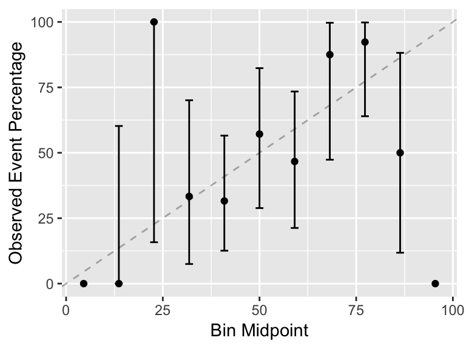

```r
Donner$pred <- predict(fit, type="response")
cal <- calibration(factor(survived, levels = c(1,0))~pred, data = Donner)
ggplot(cal, bwidth=2, dwidth = 3)
```

## Calibration plot by data quantiles

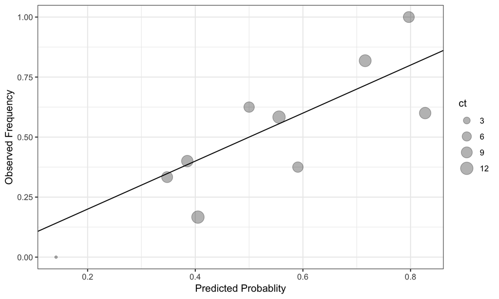

## Calibration plot including age squared

| term | estimate | std.error | statistic | p.value |
| --- | --- | --- | --- | --- |
| (Intercept) | 0.941 | 0.586 | 1.606 | 0.108 |
| age | 0.066 | 0.056 | 1.192 | 0.233 |
| I(age^2) | -0.002 | 0.001 | -1.687 | 0.092 |
| sexMale | -1.375 | 0.507 | -2.713 | 0.007 |

```
##
##  Hosmer and Lemeshow test (binary model)
##
## data:  Donner$survived, fitted(fit_sq)
## X-squared = 10.217, df = 8, p-value = 0.2501
```

## Compare models using Chi-squared

```r
anova(fit, fit_sq, test = "Chisq")
```

```
## Analysis of Deviance Table
##
## Model 1: survived ~ age + sex
## Model 2: survived ~ age + I(age^2) + sex
##   Resid. Df Resid. Dev Df Deviance Pr(>Chi)
## 1        87     111.13
## 2        86     106.73  1   4.3962  0.03602 *
## ---
## Signif. codes:  0 '***' 0.001 '**' 0.01 '*' 0.05 '.' 0.1 ' ' 1
```

The model with age squared is a significantly better fit (p < 0.05).

## Calibration plot by quantiles

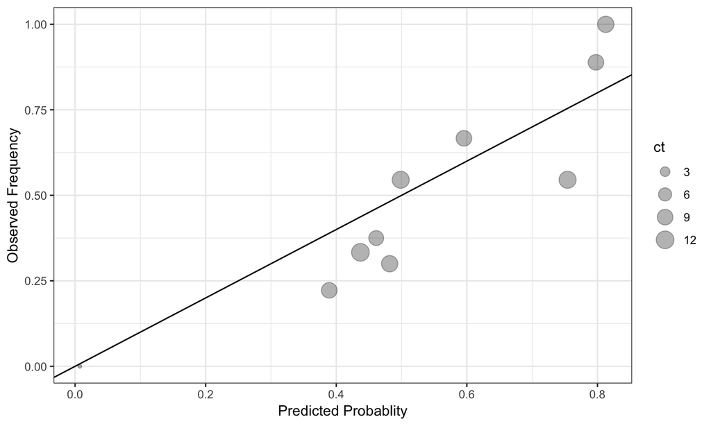

```r
cal_plot(dat = Donner, eqn = "survived ~ age + I(age^2) + sex",
         nbins = 10, quant = TRUE)
```

## Calibration plot equal bin sizes

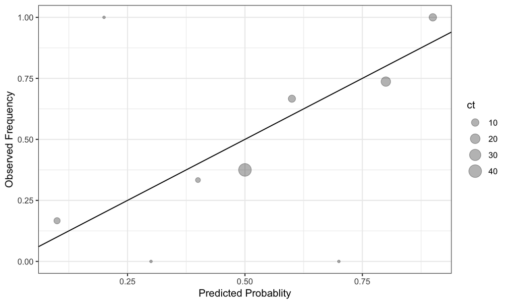

```r
cal_plot(dat = Donner, eqn = "survived ~ age + I(age^2) + sex",
         nbins = 10, quant = FALSE)
```